# DATA-413/613 Homework: Shiny

Your Name

2022-10-18

# Instructions

- Create three Apps in the appropriate folders in the homework repo in accordance with the instructions below.
- Delete any dummy files.
- For each App, put your name in a comment at the top of the `app.R` file.
- Include any citations or references in the comments as well.
- Place all of your solution Shiny code in the appropriate app folders.
- **Make sure to commit often and push each time you answer a question or you want me to look at code.**
- Submit a note on Canvas when your apps are complete and ready for scoring.
- If you want to answer the extra credit question at the end, please add your answers to your submission note on Canvas
- HINT: Use the following to guide your app development (courtesy of https://engineering-shiny.org/)

## Learning Outcomes

- Create Shiny Apps with increasing levels of sophistication.
- Use tidyverse functions to enable exploratory data analysis (EDA).
- Use `validate()` to provide meaningful feedback to users.
- Incorporate Bootswatch themes to distinguish one’s app.
- Incorporate graphical outputs and statistical tests into EDA.

## Rubric

| Part | Pts | Element |
| --- | --- | --- |
| 1.mpg App | 1.00 | App runs with proper libraries and directory structure |
| 1.mpg App | 1.00 | Correct Input layout and capabilities |
| 1.mpg App | 1.00 | Correct Output layout and plots |
| 2.mtcars App | 1.00 | App runs with proper libraries and directory structure |
| 2.mtcars App | 1.00 | Correct Input layout and capabilities |
| 2.mtcars App | 1.00 | Correct Output layout and plots |
| 3.Energy App | 1.00 | App runs with proper libraries and directory structure |
| 3.1.Business Logic | 1.00 | Data is loaded using relative path |
| 3.1.Business Logic | 2.00 | Data is properly transformed before the UI code |
| 3.1.Layout | 2.00 | Uses a Version 5 Bootswatch Theme |
| 3.1.Theme | 1.00 | User Inputs are correct in function and layout |
| 3.2.Tab 1.1 | 2.00 | User Inputs are correct in function and layout |
| 3.2.Tab 1.2 | 1.00 | Correct validation for numeric or factor |
| 3.2.Tab 1.3a | 2.00 | Histogram Plot for Numeric |
| 3.2.Tab 1.3b | 1.00 | Correct output for logscale for numeric |
| 3.2.Tab 1.3c | 1.00 | Correct messages and no plot based on using validate() and need() to test if log is appropriate |
| 3.3.Tab 1.3d | 2.00 | Proper removal of 0 values for only numeric variables of interest |
| 3.2.Tab 1.4a | 2.00 | Bar Plot for Factor |
| 3.2.Tab 1.4b | 1.00 | Correct output for factor coord flip for only factors |
| 3.2.Tab 1.4c | 1.00 | Correct messages and no plot based on using validate() and need() to test if log is appropriate |
| 3.3.Tab 1.5 | 2.00 | Correct data and plots for each year |
| 3.2.Tab 1.6a | 2.00 | Correct t.test output for numerics based on null value |
| 3.2.Tab 1.6b | 2.00 | Correct t.test output for logged numerics based on log and null value |
| 3.2.Tab 1.6c | 1.00 | Correct messages and no plot based on using validate() and need() to test if log is appropriate |
| 3.3.Tab 1.6d | 1.00 | Proper removal of NAs and 0 values for t.test |
| 3.3.Tab 2.1 | 2.00 | User Inputs are correct in function and layout |
| 3.3.Tab 2.2a | 2.00 | Correct scatter plots for Numeric and Numeric based on log or no log |
| 3.2.Tab 2.2b | 2.00 | Correct messages and no plot based on using validate() and need() to test if log is appropriate |
| 3.3.Tab 2.2c | 2.00 | Proper removal of 0 values for only numeric variables of interest |
| 3.3.Tab 2.3a | 2.00 | Boxplots for Numeric and Factor based on log or no log |
| 3.2.Tab 2.3b | 1.00 | Correct messages and no plot based on using validate() and need() to test if log is appropriate |
| 3.3.Tab 2.4a | 2.00 | Jitter Plot for Factor and Factor |
| 3.3.Tab 2.4b | 1.00 | Correct messages and no plot based on using validate() and need() to test if log is appropriate |
| 3.3.Tab 2.5 | 2.00 | Correct data and plot output for each year |
| 3.3.Tab 2.6 | 1.00 | Correct output for selected OLS Input |
| 3.3.Tab 2 Extra Credit | 1.00 | EC: LM Summary in proper layout with no error messages |
| 3.3.Tab 2 Extra Credit | 1.00 | Correct messages and no plot based on using validate() and need() to test if log is appropriate |
| 3.3.Tab 2 Extra Credit | .50 | EC: Residual Plot in proper layout with no error messages |
| 3.3.Tab 2 Extra Credit | .50 | EC: QQ Plot in proper layour with no error messages |
| 3.4.Tab 3.1 | .50 | Correct Input options for Data Table |
| 3.4.Tab 3.2 | .50 | Correct Output layout for Data Table |
| 3.4.Tab 3.3 | 1.00 | Correct Data for Data Table |
| 4.Extra Credit Webinar | 1.00 | Reasonable answers to questions |
| **Total** | **50** | Plus Extra Credit |

# 1 Create a Shiny app for EDA of the `mpg` Dataset

- Allow a user to select any three variables from the `mpg` data frame in the {ggplot2} package.
- The app should output a scatterplot of two of the variables and color code the points by the third variable.
- Make the default variables the ones in the image below.
- Your app should look similar to this:

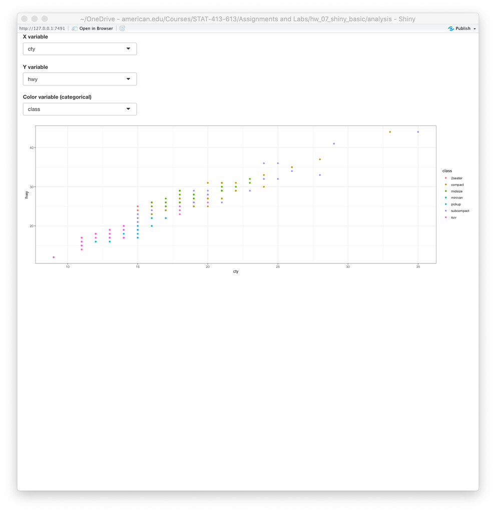

# 2 Create a Shiny App for EDA of the mtcars Data.

- Allow users to select a variable from the `mtcars` dataset as well as the type of plot (histogram, density, or frequency polygon).
- Create a plot of the selected type for the selected variable
- Match the output shown below:
- Hint 1: Recall plots are objects built by adding up layers for the aesthetics, geoms, scales, etc., one layer. the first layer is the call to `ggplot()` and then you add more layers with a `+`. You can save the plot object at each time and refer to it later to add more layers. As an example `my_plot <- ggplot(df, aes(var1)` followed by `my_plot <- my_plot + geom_point()`. You can put these steps inside other functions as well and/or assign each layer to its own variable, e.g., `my_plot_geom <- geom_point()` and then `my_plot <- my_plot + my_plot_geom`. Taking advantage of this feature of {ggplot2} will make your code shorter, simpler, and more robust.
- Hint 2: Consider using `if` statements or `dplyr::case_when` or base R `switch()`.
- Your app should look similar to this:

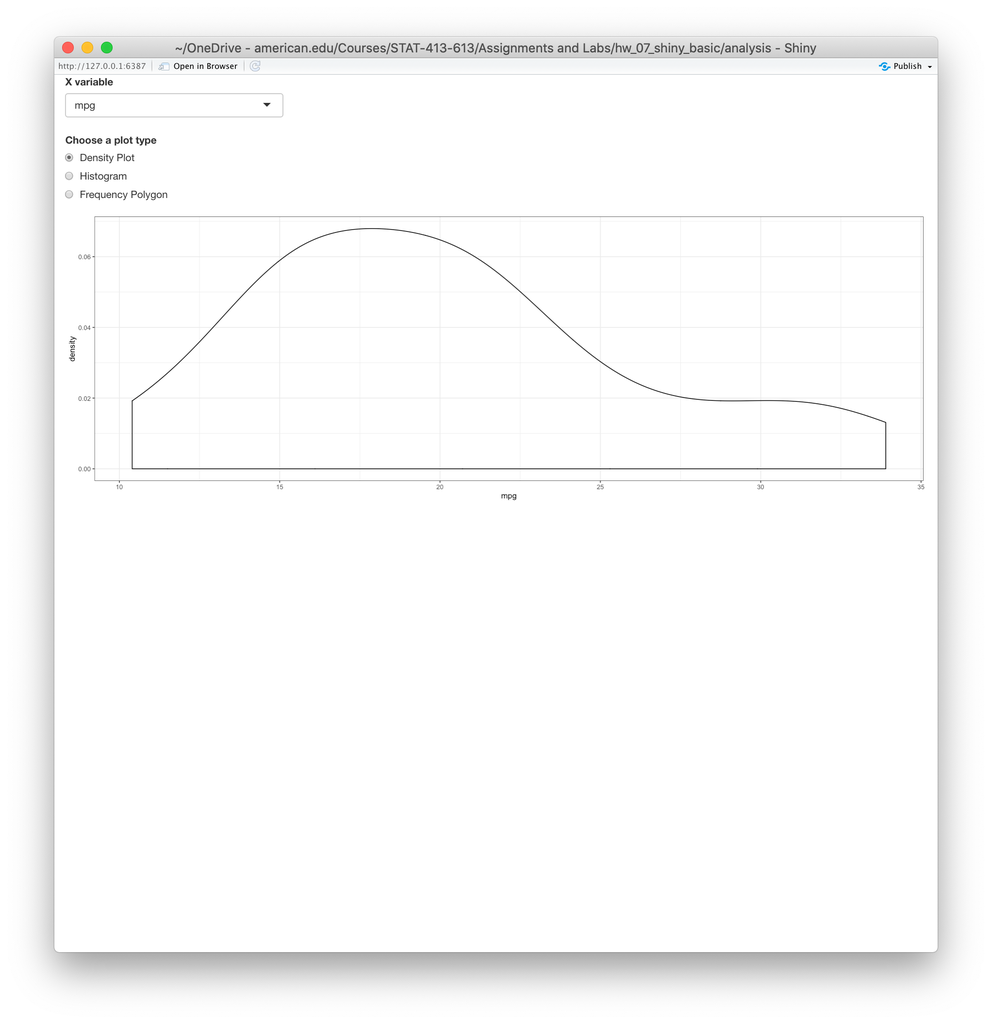

# 3 Exploratory Data Analysis of Washington, DC Building Energy Performance

## 3.1 Introduction and Background on the Data

The city of Washington, DC Department of Energy & Environment (DOEE) collects data on public and private building energy performance disclosed under the Building Energy Performance Standards (BEPS) Program. This assignment uses a subset of that data downloaded in from [DC Open data](https://opendata.dc.gov/datasets/DCGIS::building-energy-performance/about). The subset has been filtered to produce a cleaner data set. The variables have also been renamed.

However, this is about ~11K rows of real data. It has some issues due to how people report or don’t report correctly. You may get what look like strange results at first but the point here is to allow someone to look at a lot of data quickly to identify potential relationships or issues.

The data is in the `energy_year.rds` file in the `data` folder of the sample app. Do not move the data. Use a relative path to load it in your business logic section.

| Variable | Definition |
| --- | --- |
| ID | ID number from Portfolio Manager—this serves as the unique key for each record. |
| Name | Name of property as reported by owner |
| Report_Year | Last Day of Reporting Year |
| Ward | Ward as recorded by the DC Office of Tax and Revenue |
| Built | The year property was constructed |
| Type_SS | The Primary Use of the Property, as self-selected by owner. |
| Type_EPA | The Primary Use of the Property, as calculated by EPA Portfolio Manager |
| SQFT_Tax | The Gross Floor Area as recorded by the DC Office of Tax and Revenue in square feet |
| SQFT_Gross | The Gross Floor Area as reported by owner, in square feet. The Gross Floor Area is the total size, as measured between the principal exterior surfaces of the enclosing fixed walls of the building(s). … |
| Energy_Star_Score | The 1‐100 score calculated by ENERGY STAR Portfolio Manager® that measures how well the property is performing relative to similar properties, when normalized for climate and operational characteristi… |
| Site_EUI | The Site Energy Use Intensity (EUI), as calculated by Portfolio Manager, at the property site. This equals the amount of energy consumed at the site in thousand British thermal units (kBtus) per gross… |
| Site_EUI_Weather_Normed | Weather normalized Site Energy Use Intensity is the Site EUI in kBtu/ft2 of the property, normalized for weather. Weather normalization facilitates the comparison between different parts of the countr… |
| Source_EUI | Source Energy Use divided by property square footage, normalized for weather. Weather‐normalization is based on National Oceanic and Atmospheric Administration (NOAA) weather data for the zip code. |
| Source_EUI_Weather_Normed | Source EUI (kBtu/ft2) of the property, normalized for weather. Weather normalization facilitates comparison between different parts of the country and corrects for year-to‐year differences in weather. |
| GH_Gas | Greenhouse Gas (GHG) Emissions are expressed in Metric Tons of carbon dioxide equivalent (CO2e). Total Emissions is the sum of Direct Emissions (emissions associated with onsite fuel combustion) and I… |
| GH_Gas_Intensity | The total Greenhouse Gas (GHG) Emissions, divided by the floor area of the building, in kilograms of carbon dioxide equivalent (CO2e) per square foot. |
| Water_Score | EPA’s 1-100 Water Score for Multifamily Housing, is a measure of how efficiently your property is using water, compared to similar properties, when normalized for climate and operational characteristi… |
| Water_Usage | Total annual water consumption in kilogallons (1,000 gallons). |
| Natural_Gas_Usage | The total annual natural gas consumed by the property. |
| Fuel_Oil_Diesel_Usage | Total annual energy consumption from liquid fuel use on the property. |
| Metered_Energy | The portions of the building for which energy use was reported |
| Metered_Water | The portions of the building for which water use was reported, according to EPA. (Note that water data is almost always metered at the whole building level in DC, so a blank value here is usually not … |
| Dist_Chilled_Water_Usage | Total annual energy consumption from District Chilled Water. |
| Dist_Hot_Water_Usage | Total annual energy consumption from District Hot Water. |
| Dist_Steam_Usage | Total annual energy consumption from District Steam systems |
| Electricity_Renewable_Usage | The total annual electricity consumed by the property generated and used onsite from any onsite renewable energy generation systems |
| Electricity_Grid_Usage | The total annual electricity consumed by the property sourced from the electrical grid. |
| Latitude | Geographic coordinate that specifies the north–south position of a point on the Earth’s surface |
| Longitude | Geographic coordinate that specifies the east‐west position of a point on the Earth’s surface |

- Select [View All Metadata](https://opendata.dc.gov/datasets/DCGIS::building-energy-performance/about) near the bottom right of the page.

Per EPA on [Source vs Site](https://www.energystar.gov/buildings/benchmark/understand_metrics/source_site_difference) source energy is the most equitable unit of evaluation for comparing different buildings to each other. Source energy represents the total amount of raw fuel that is required to operate the building. It incorporates all transmission, delivery, and production losses. By taking all energy use into account, the score provides a complete assessment of energy efficiency in a building. Site energy is the amount of heat and electricity consumed by a building as reflected in your utility bills. Looking at site energy can help you understand how the energy use for an individual building has changed over time.

## 3.2 Build a Shiny App to Enable Exploratory Data Analysis

**Review the [Sample App](https://r2ressler.shinyapps.io/shiny_dc_energy/).** Other than the theme, try to match the layout and functionality.

- This is a new app so may have some bugs. If you think you found one, please let me know or ask a question!
- **Save and commit your work often!!** Be prepared for R to crash.
- The app should meet the following requirements::
0. General:
- Transform the data so `Report_Year`, `Type_SS`, `Type_EPA`, `Metered_Energy` and `Metered_Water` are factors.
- Create a new factor variable called `Era` which has the following levels (inorder) based on the values for `Built`:
  - Built < 1900 “Pre-1900”,
  - Built < 1951 “Early-Mid 20th”,
  - Built < 2000 “Late 20th”,
  - Built < 2011 “Aughts”,
  - otherwise “Teens and later”
- Select a Bootswatch version 5 theme for the App.
1. Three tabs. The first tab is for univariate analysis. The second tab is for bivariate analysis. The third tab is for a spreadsheet of the numeric variables in the data.
2. For the univariate analysis:
- Allow the user to select:
  - The variable of interest.
  - One or more Report years of interest. Set the initial selected value to only 2020.
  - Whether to flip the coordinates for a factor variable?
  - Whether to log transform the variable?
  - The number of bins in the histogram.
  - The null value for true population mean for a one-sample t-test.
- Output the following:
  - An error message if the variable selected is not numeric or a factor - use `validate()`.
  - A histogram if the variable is numeric and a barplot otherwise.
  - Flipped coordinates for a factor if selected.
  - A plot *for each year selected*, i.e., facet.
  - Use a log scale if log_transform is selected.
  - An error message if the user selects log transform on a variable with one or more values <= 0. Use `validate()` with `need()`.
  - An error message if the user selects log transform on a factor variable. Use `validate()`with `need()`.
  - The results of the one-sample t-test. The results of the test should be in accordance with the user’s choice of a log transformation (or not) for the data.
    - An error message if the user selects a non-numeric variable. Use `validate()`with `need()`.
    - An error message if the user selects log for a variable than has values <= 0. Use `validate()`with `need()`.
    - Note: to test your results, enter a null value close to the estimate in your running app, else the p value will be 0.
3. For the bivariate analysis:
- Allow the user to select:
  - The variable of interest for the X axis.
  - Whether to log transform the variable for the X axis.
  - The variable of interest for the Y axis .
  - Whether to log transform the variable for the Y axis.
  - Whether to add an OLS line.
  - One or more Report years of interest. Set the initial selected value to only 2020.
- Output the following:
  - An error message if the variable selected is not numeric or a factor. Use `validate()` with `need()`.
  - If both variables are numeric, a scatter plot.
    - Indicate each year that is selected by color
  - If one is numeric and one is categorical, a boxplot.
  - If both variables are categorical, a jitter plot.
  - Add a log scale if log_transform is selected.
    - An error message if the user selects log transform on a variable with one or more values <= 0. Use `validate()`with need.
    - An error message if the user selects log transform on a factor variable. Use `validate()`with need.
  - Add a single linear smoother if the OLS line is selected.
- **Extra Credit** for **only if OLS is checked**:
  - Add another row of output:
  - On the left, a summary from running a linear model on the chosen inputs and outputs to include any log transforms
  - Output an error message if attempting to use a Factor variable for Y. Use `validate()` with `need()`.
  - In the middle, output a plot of the residuals (Y) and fitted values (X)
  - On the right, output a QQ plot using `geom_qq()` and `geom_qq_line()`
4. The third tab should show a Data Table
- Input: Allow the user to select whether to see only the numeric or factor variables. Use a {purrr} function to select these.
- Output: Show the variables per the selection. Set the page length to 20 rows.
5. Eliminate records with 0 values but **only for the selected variables**.
- This data has many records with 0s where the 0 means either truly 0 or just not recorded.
- Since these 0s are not of interest, when preparing the data for a plot, remove records that have a value of 0 for the variables of interest.

## 3.3 Suggestions

- Use comments to separate your code for both UI and Server into sections for each tab.
- Take advantage of the modularity built into {ggplot2} in conjunction with if-else statements to ensure you are tracking the variables types and whether the data has been asked to be logged. Write out your logic flow to ensure you have all cases covered without duplicating a lot of code.

  ```r
  pl <- ggplot(mtcars, aes(x = disp, y = mpg))
  if (...){
  pl <- pl + geom_point()
  } else if(...){
  pl <- pl + scale_x_log10()
  }
  pl
  ```

- Use a reactive function to filter the data to just the rows selected for Report Years at the beginning of the server function for each tab, e.g., create a `df()` object you can use in the rest of the code.
- You may want to use the same reactive to select the variables of interest and remove the rows != 0.
- **Review the discussion about using variables selected from data frames in non-tidyverse functions, e.g., `is.numeric()`, `t.test()`, `lm()`, at the end of the Part A lecture notes.**
- **Use the RStudio Debug environment by inserting breakpoints in the Business Logic or Server Section code.** If the breakoints are not working for you, insert a browser()` function inside the reactive function (reactive or renderXXX) but be sure to delete it when finished.
- **Build a little, test a little**.
  - Build the business logic section
  - Build the framework of three tabs with no content
  - Build Tab 1 Code
    - Build the inputs
    - Build the code for the reactive function to filter by rows
    - Add the code for plot type
    - Add the code for log transform
    - Add the code for t-test
    - Add the code for t-test - with log transformed data
    - Add the code to remove values = 0
    - Add the code to flip coordinates for factors
    - Add all the validate checks.
  - Build Tab 2 Code
    - Build the inputs
    - Add the code for the reactive function to filter by rows
    - Add the code for plot type
    - Add the code for log transform
    - Add the code for OLS
    - Add all the validate checks.
  - Build Tab 3 Code
    - Build the input
    - Add the code to display the DataTable and set the page length
    - Build the code to select the columns using {purrr}
  - Build the Extra Credit Code for Tab 2
    - Build the LM using a reactive function and save the output
    - Add the code to render the summary results
    - Add the code to plot the residuals
    - Add the code for the QQ plot
    - Add all the validate checks.
- Ask Questions!

# 4 Extra Credit Webinar

- Listen to the first 30 minutes of [Episode 22: A fresh coat of Shiny theming with Carson Sievert](https://shinydevseries.com/interview/ep022/) of the RStudio Shiny Developer Series” webinars answer the following question:
1. How do new capabilities of {bslib} and {thematic} for creating and using custom themes affect how you think about your design of colors and fonts?